# Piotr Bajger - Etapy 3 i 4.

Piotr Bajger

11 czerwca 2017

## 3.1. Wczytanie i przygotowanie danych

Celem Etapów 3 i 4 jest przygotowanie danych oraz rozszerzenia modeli z Etapów 1 i 2 o cechy ucznia, tzn. skonstruowanie modelu predykcji czasu potrzebnego na rozwiązanie zadania z części matematycznej testu PISA 2015 na podstawie cech zadania (ID, pozycja w kwestionariuszu) oraz dodatkowo wybranych cech ucznia z pliku **CY6_MS_CMB_STU_QQQ.sav** (płeć, kraj pochodzenia, wykształcenia rodziców, licbę książek w gospodarstwie domowym na tematy związane ze sztuką oraz liczbę instrumentów muzycznych).

Ze względu na rozmiar danych i długi czas potrzebny na obliczenia, wybieramy w sposób losowy podzbiór (40%) ID uczniów *CNTSTUID*. Biorąc pod uwagę, że powyższy zabieg zmniejsza liczbę naszych obserwacji do ok. 800 tysięcy (z ok. 2 milionów), mamy przekonanie, że nie zaburzy to w znaczący sposób wyników modelu.

W rezultacie otrzymamy zbiór o następującej strukturze:

```r
head(qTime34)
```

```
##   CNTSTUID      T question position     logT       CNT gender
## 1  3600005 116448     M00G        3 11.66520 AUS         Male
## 2  3600005 166486     M905        4 12.02267 AUS         Male
## 3  3600005 265274     M909        3 12.48852 AUS         Male
## 4  3600005 223483     M919        4 12.31709 AUS         Male
## 5  3600005 122621     M943        4 11.71685 AUS         Male
## 6  3600005 374350     M949        3 12.83295 AUS         Male
##             mother_edu           father_edu art_books musical_instr
## 1 <ISCED level 3B, 3C> <ISCED level 3B, 3C>       Yes Three or more
## 2 <ISCED level 3B, 3C> <ISCED level 3B, 3C>       Yes Three or more
## 3 <ISCED level 3B, 3C> <ISCED level 3B, 3C>       Yes Three or more
## 4 <ISCED level 3B, 3C> <ISCED level 3B, 3C>       Yes Three or more
## 5 <ISCED level 3B, 3C> <ISCED level 3B, 3C>       Yes Three or more
## 6 <ISCED level 3B, 3C> <ISCED level 3B, 3C>       Yes Three or more
```

## 3.2 Wizualizacja danych

Poniżej przedstawiam boxploty oraz wykresy średnich dla wszystkich poziomów zmiennych, które rozważam.

### 3.2.1 Kraj i płeć

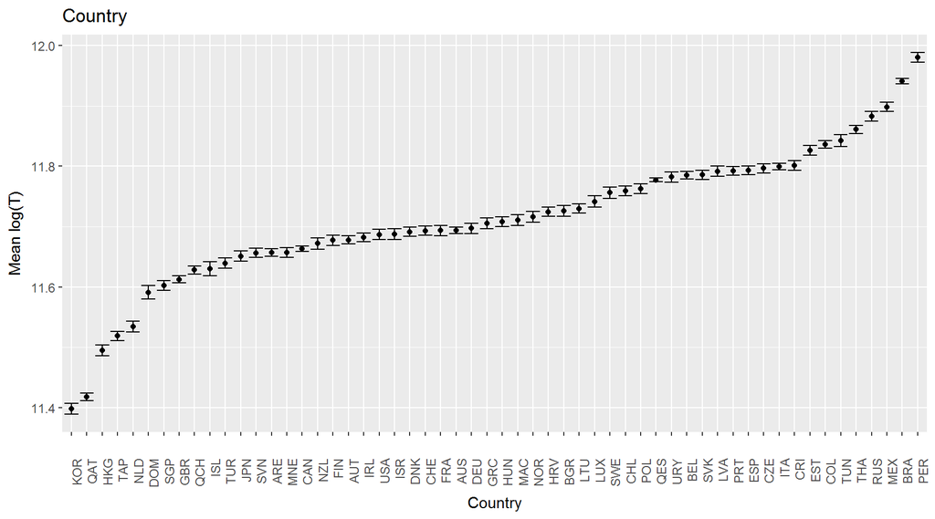

```r
qTimeStudSum <- summarySE(qTime34, measurevar="logT", groupvars=c("CNT"))

ggplot(qTimeStudSum, aes(x=reorder(CNT, logT), y=logT)) + geom_point(position = position_dodge(.1), stat="identity") + geom_errorbar(aes(ymin=logT-se, ymax=logT+se), position = position_dodge(.1)) + theme(axis.text.x = element_text(angle = 90, hjust = 1)) + labs(x = "Country", y = "Mean log(T)") + ggtitle(label = "Country")
```

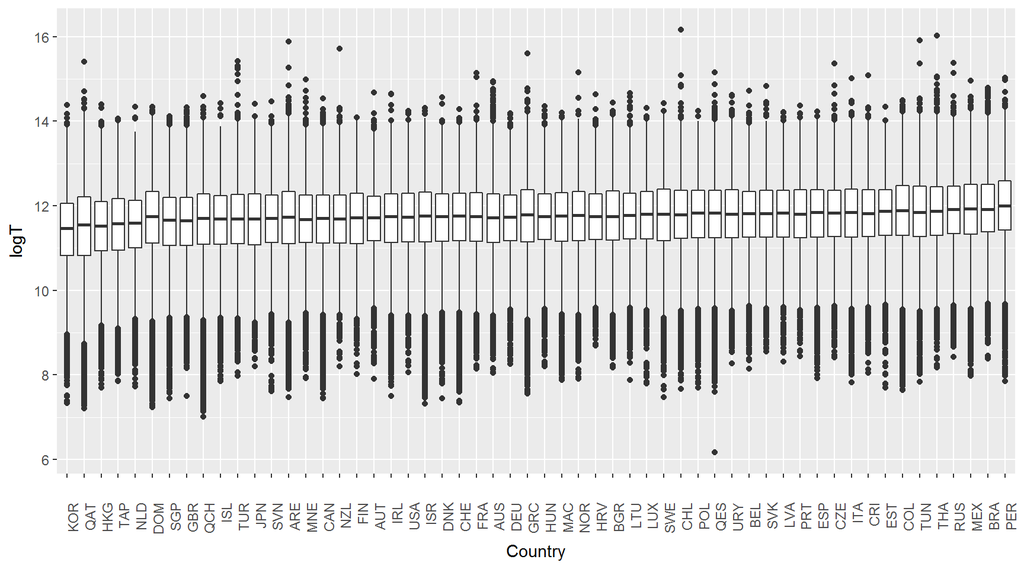

```r
ggplot(qTime34, aes(x=reorder(CNT, logT, FUN=mean), y=logT)) + geom_boxplot() + theme(axis.text.x = element_text(angle = 90, hjust = 1))+ labs(x = "Country")
```

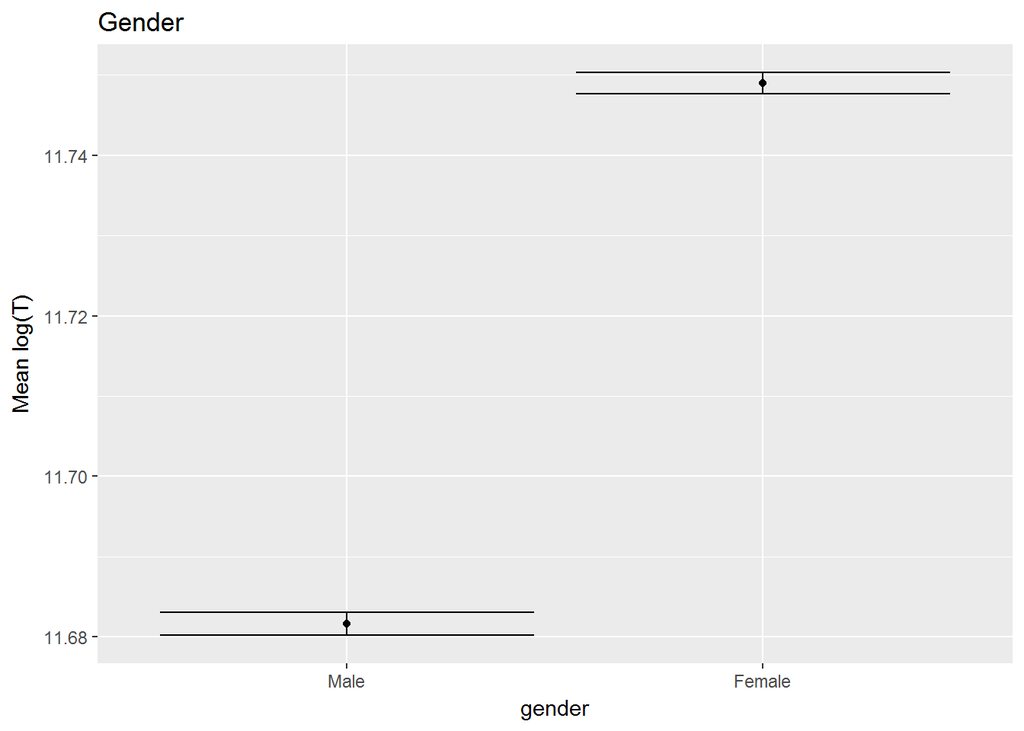

```r
qTimeStudSum <- summarySE(qTime34, measurevar="logT", groupvars=c("gender"))

ggplot(qTimeStudSum, aes(x=reorder(gender, logT), y=logT)) + geom_point(position=position_dodge(.1), stat="identity") + geom_errorbar(aes(ymin=logT-se, ymax=logT+se), position = position_dodge(.1)) + labs(x="gender", y = "Mean log(T)") + ggtitle(label = "Gender")
```

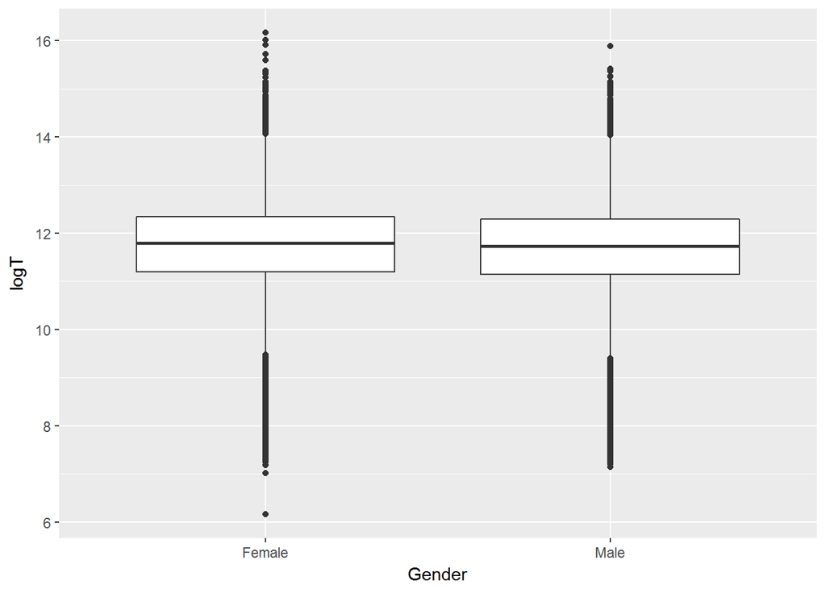

```r
ggplot(qTime34, aes(gender, logT)) + geom_boxplot() + labs(x = "Gender")
```

### 3.2.2 Książki i instrumenty muzyczne

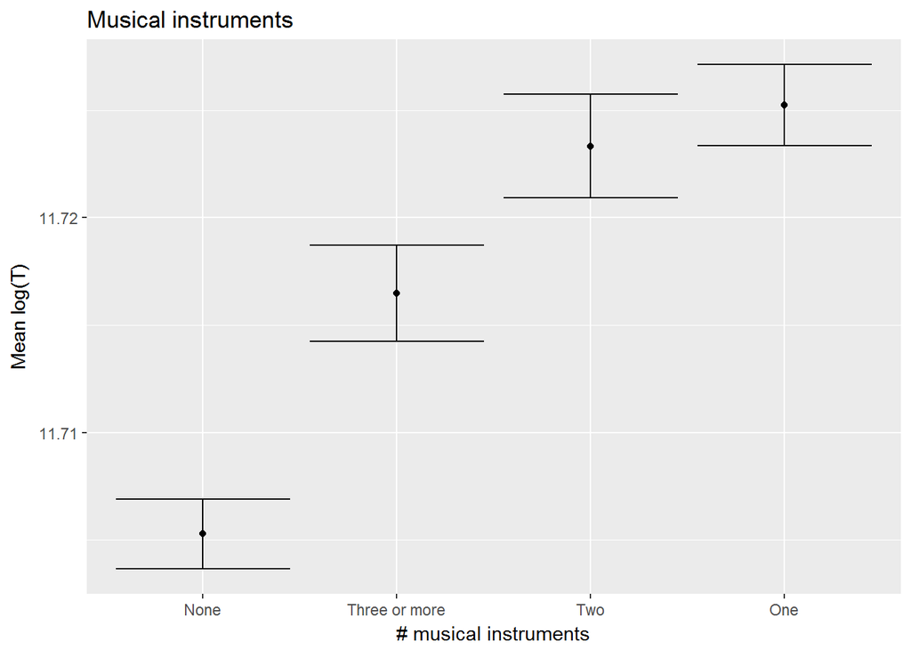

```r
qTimeStudSum <- summarySE(qTime34, measurevar="logT", groupvars=c("musical_instr"))

ggplot(qTimeStudSum, aes(x=reorder(musical_instr, logT), y=logT)) + geom_point(position=position_dodge(.1), stat="identity") + geom_errorbar(aes(ymin=logT-se, ymax=logT+se), position = position_dodge(.1)) + labs(x="# musical instruments", y = "Mean log(T)") + ggtitle(label = "Musical instruments")
```

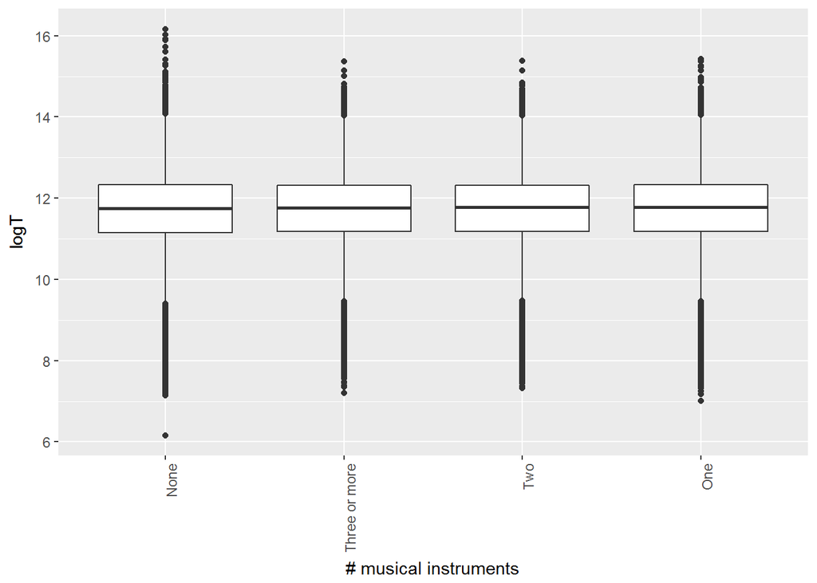

```r
ggplot(qTime34, aes(x=reorder(musical_instr, logT, FUN=mean), y=logT)) + geom_boxplot() + theme(axis.text.x = element_text(angle = 90, hjust = 1)) + labs(x = "# musical instruments")
```

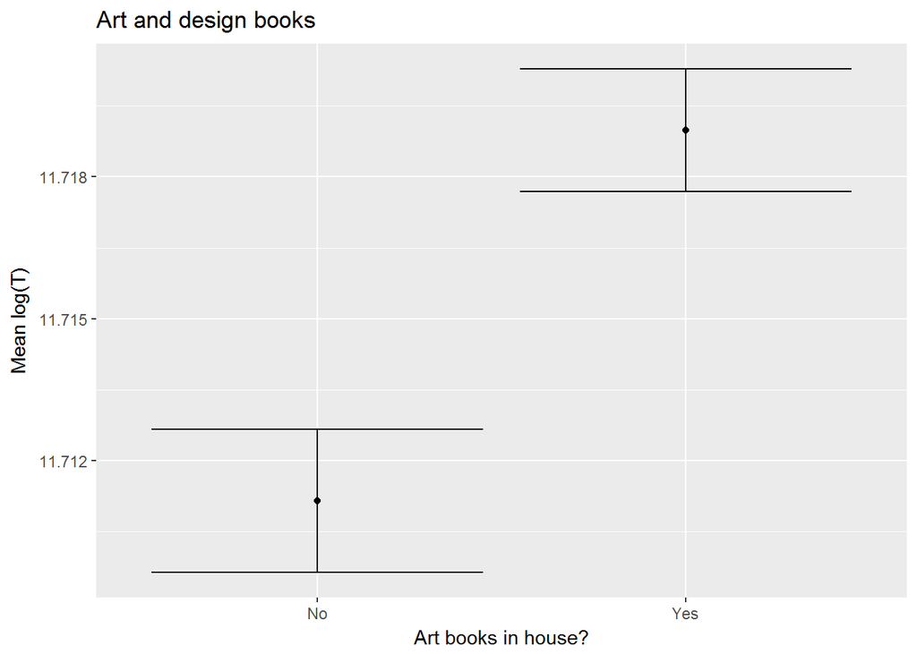

```r
qTimeStudSum <- summarySE(qTime34, measurevar="logT", groupvars=c("art_books"))

ggplot(qTimeStudSum, aes(x=reorder(art_books, logT), y=logT)) + geom_point(position=position_dodge(.1), stat="identity") + geom_errorbar(aes(ymin=logT-se, ymax=logT+se), position = position_dodge(.1)) + labs(x="Art books in house?", y = "Mean log(T)") + ggtitle(label = "Art and design books")
```

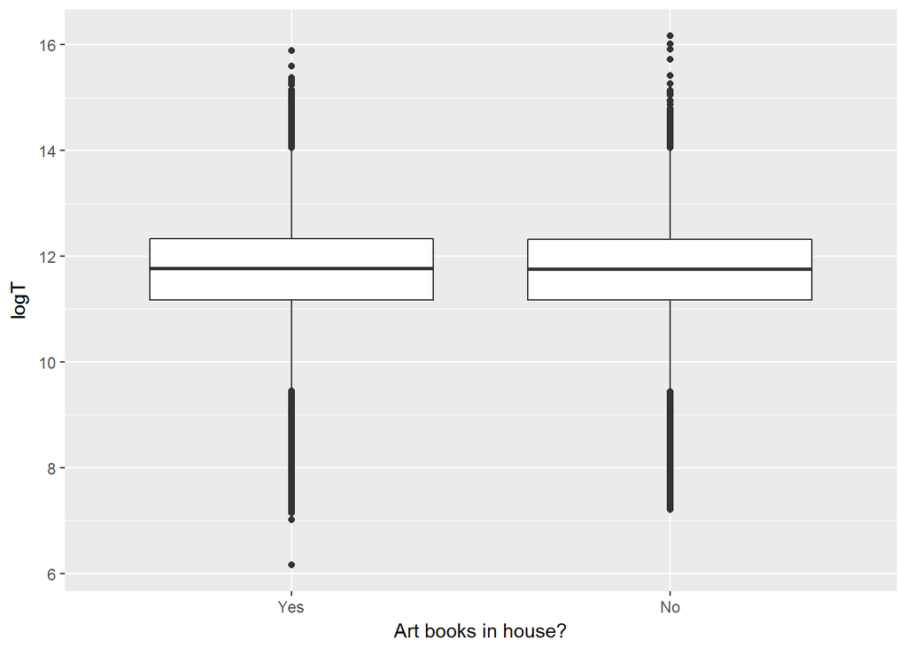

```r
ggplot(qTime34, aes(art_books, logT)) + geom_boxplot() + labs(x = "Art books in house?")
```

### 3.2.3 Wykształcenie rodziców

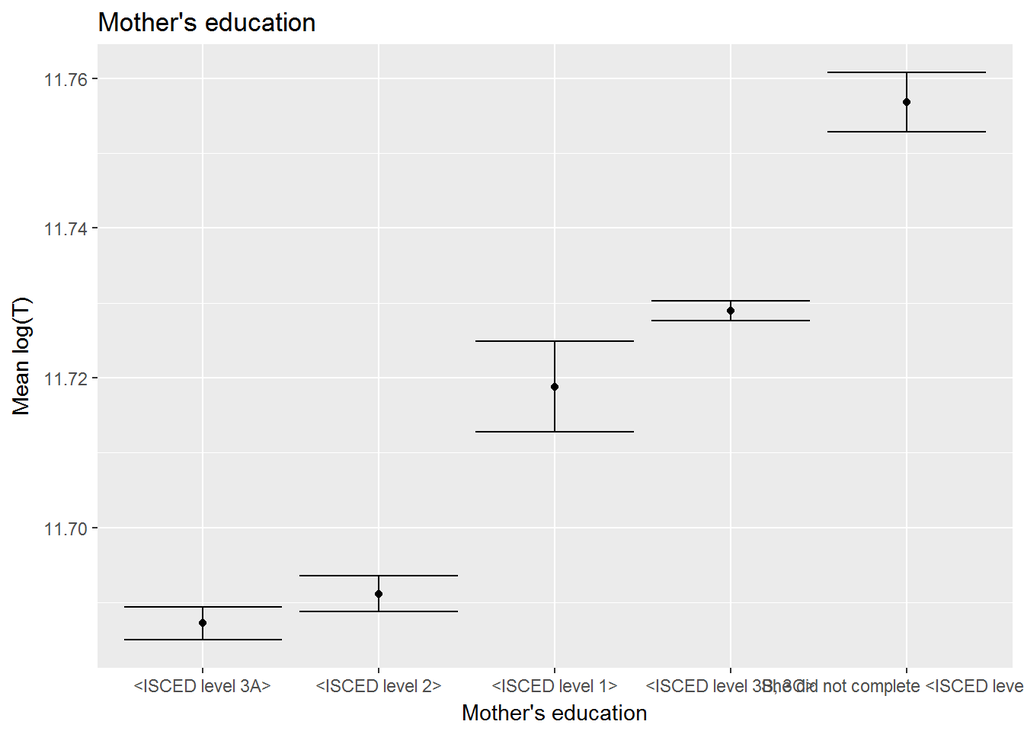

```r
qTimeStudSum <- summarySE(qTime34, measurevar="logT", groupvars=c("mother_edu"))

ggplot(qTimeStudSum, aes(x=reorder(mother_edu, logT), y=logT)) + geom_point(position=position_dodge(.1), stat="identity") + geom_errorbar(aes(ymin=logT-se, ymax=logT+se), position = position_dodge(.1)) + labs(x="Mother's education", y = "Mean log(T)") + ggtitle(label = "Mother's education")
```

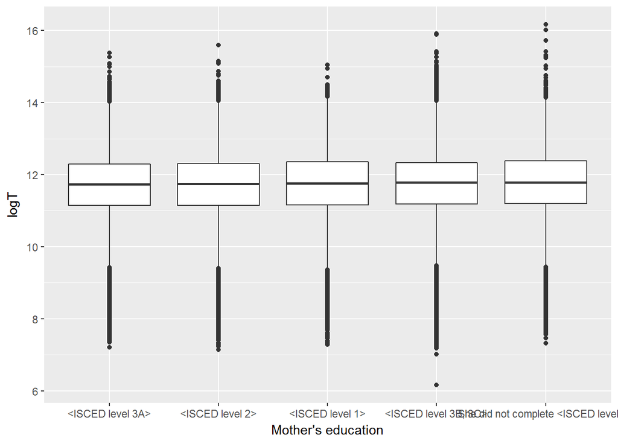

```r
ggplot(qTime34, aes(x=reorder(mother_edu, logT, FUN=mean), logT)) + geom_boxplot() + labs(x = "Mother's education")
```

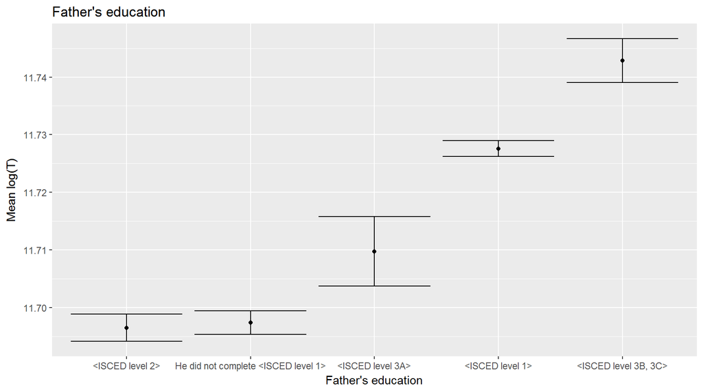

```r
#Ustawienie leveli, by były w kolejności od najniższego do najwyższego poziomu edukacji
levels(qTime34$mother_edu) <- levels(qTime34$mother_edu)[c(5, 4, 3, 1, 2)]
levels(qTime34$father_edu) <- levels(qTime34$father_edu)[c(5, 4, 3, 1, 2)]

qTimeStudSum <- summarySE(qTime34, measurevar="logT", groupvars=c("father_edu"))

ggplot(qTimeStudSum, aes(x=reorder(father_edu, logT), y=logT)) + geom_point(position=position_dodge(.1), stat="identity") + geom_errorbar(aes(ymin=logT-se, ymax=logT+se), position = position_dodge(.1)) + labs(x="Father's education", y = "Mean log(T)") + ggtitle(label = "Father's education")
```

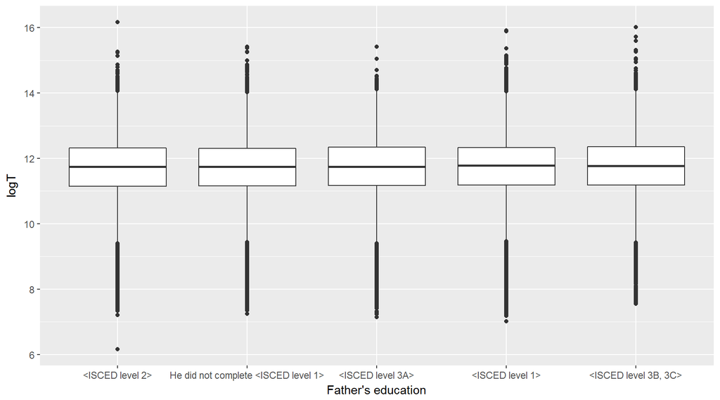

```r
ggplot(qTime34, aes(x=reorder(father_edu, logT, FUN=mean), logT)) + geom_boxplot() + labs(x = "Father's education")
```

Wizualizacja interakcji między wykształceniami rodziców:

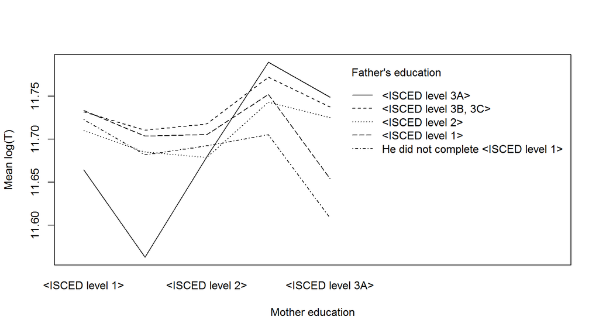

```r
interaction.plot(qTime34$mother_edu, qTime34$father_edu, qTime34$logT, xlab = "Mother education", ylab = "Mean log(T)", trace.label = "Father's education")
```

## 3.2 Konstrukcja i wybór modelu

Naszym celem będzie rozszerzenie modelu liniowego skonstruowanego w Etapie 1. i 2. W tym celu rozważymy korzyści, które płyną z dodania nowych zmiennych do naszego modelu. Rozważyliśmy wszystkie 63 możliwe (niepuste) kombinacje sześciu zmiennych i wybierzemy model minimalizujący kryterium BIC. Okazuje się, że model zawierający wszystkie sześć zmiennych minimalizuje kryterium BIC, więc to on będzie przedmiotem naszych dalszych badań.

Wyniki naszej analizy modeli przedstawiamy na wykresie poniżej. Na czerwono zaznaczono modele, które zawierają zmienną *CNT*, czyli kraj pochodzenia ucznia. Posiada najwięcej poziomów, ze wszystkich zmiennych, które rozważamy i jednocześnie najbardziej poprawia kryterium BIC.

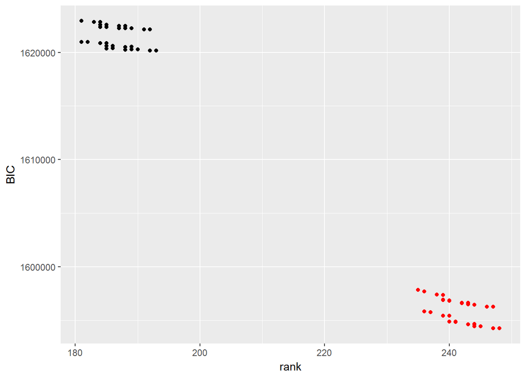

```r
params <- as.data.frame(params)
colnames(params) <- c("BIC", "rank", "adjR2", "AIC")
ggplot(params, aes(rank, BIC)) + geom_point() + geom_point(data=params[which(wsp[,1] == TRUE),], color = 'red')
```

Istotność statystyczną wszystkich użytych zmiennych potwierdza jednokierunkowa analiza wariancji:

```r
model <- lm(logT ~ CNT + gender + mother_edu + father_edu + art_books + musical_instr + as.factor(position)/question, qTime34)
aovar <- aov(model)
summary(aovar)
```

```
##                                  Df Sum Sq Mean Sq F value   Pr(>F)
## CNT                              55  11284     205  468.92  < 2e-16 ***
## gender                            1    865     865 1977.55  < 2e-16 ***
## mother_edu                        4    486     122  277.88  < 2e-16 ***
## father_edu                        4    206      51  117.52  < 2e-16 ***
## art_books                         1      6       6   14.29 0.000157 ***
## musical_instr                     3     80      27   61.04  < 2e-16 ***
## as.factor(position)               3  10037    3346 7646.41  < 2e-16 ***
## as.factor(position):question    176 240428    1366 3122.11  < 2e-16 ***
## Residuals                    790850 346034       0
## ---
## Signif. codes:  0 '***' 0.001 '**' 0.01 '*' 0.05 '.' 0.1 ' ' 1
```

## 3.4 Testy post hoc

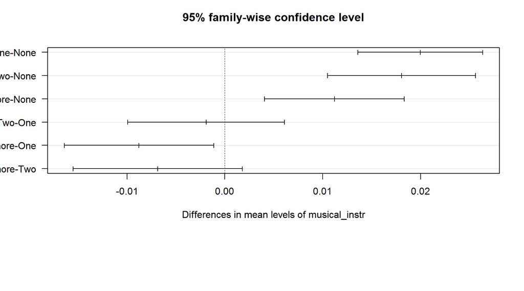

```r
aov_instr <- aov(logT ~ musical_instr, data = qTime34)

op <- par(mar = c(10,4,4,2) + 0.1) #set marigins
plot(TukeyHSD(aov_instr), las = 1)
```

```r
par(op)
```

```r
qTime34$musical_instr_yn <- ifelse(qTime34$musical_instr == 'None', 'No', 'Yes')
summary(aov(lm(logT ~ musical_instr_yn, qTime34)))
```

```
##                      Df Sum Sq Mean Sq F value Pr(>F)
## musical_instr_yn      1     53   52.86   68.62 <2e-16 ***
## Residuals        791096 609374    0.77
## ---
## Signif. codes:  0 '***' 0.001 '**' 0.01 '*' 0.05 '.' 0.1 ' ' 1
```

W ten sposób konstruujemy nowy model liniowy, którego użyjemy do dalszej analizy:

```r
model <- lm(logT ~ CNT + gender + mother_edu + father_edu + art_books + musical_instr_yn + position + position/question, qTime34)
```

## 3.5 Wizualizacja modelu

```r
#Beta:
#2 - 56: CNT
#57: gender
#58 - 61: mother_edu
#62 - 65: father_edu
#66: art_books
#67: musical_instr_yn
#68 - 70: position
#71 - 246: position / question

coeff.names <- names(model$coefficients)
coeff <- model$coefficients
```

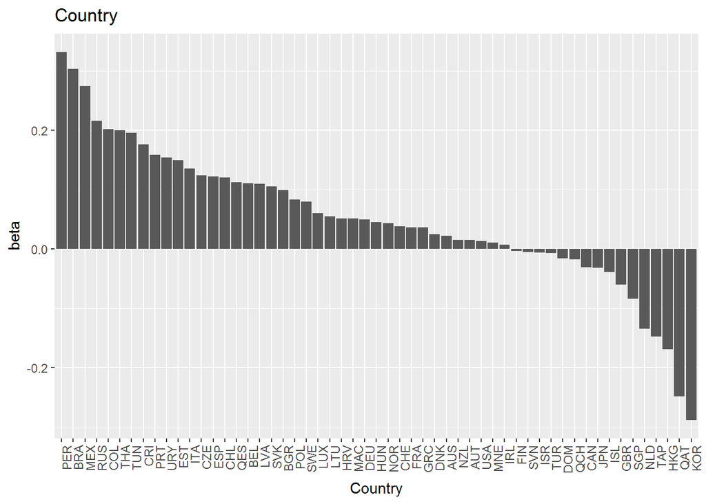

```r
cnt.names <- unlist(lapply(X = coeff.names[2:56], FUN = function(x) substr(x, 4, 6)))

coeff.df <- data.frame(beta = unname(coeff[2:56]), country = cnt.names)

ggplot(coeff.df, aes(x=reorder(country, -beta), y=beta)) + geom_bar(position = 'dodge', stat = 'identity')+ theme(axis.text.x = element_text(angle = 90, hjust = 1)) + labs(x = 'Country') + ggtitle("Country")
```

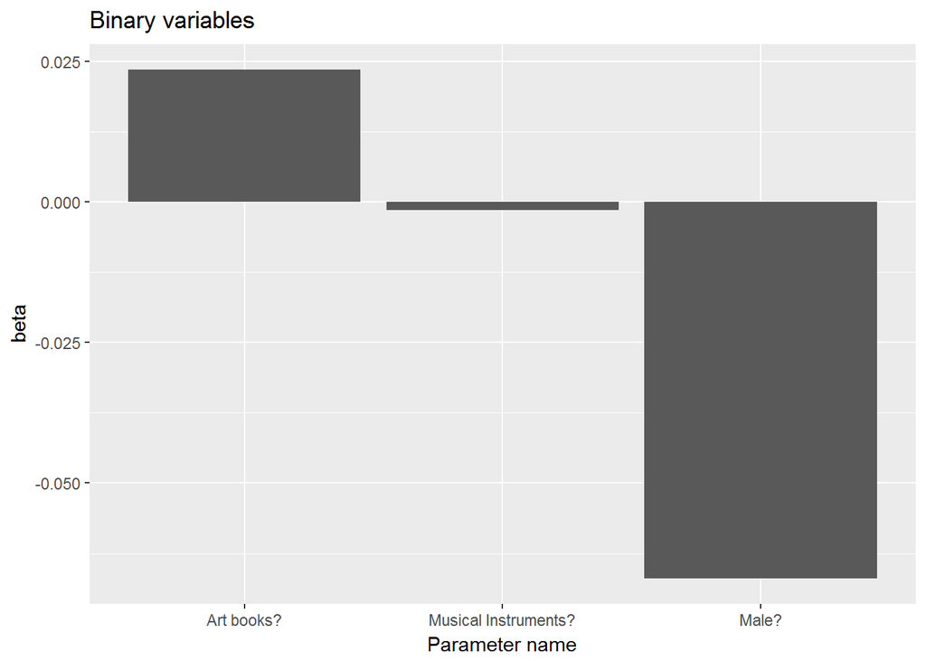

```r
coeff.df <- data.frame(beta = unname(coeff[c(57, 66, 67)]), name = c("Male?", "Musical Instruments?", "Art books?"))

ggplot(coeff.df, aes(x = reorder(name, -beta), y=beta)) + geom_bar(position = 'dodge', stat = 'identity') + labs(x = 'Parameter name') + ggtitle("Binary variables")
```

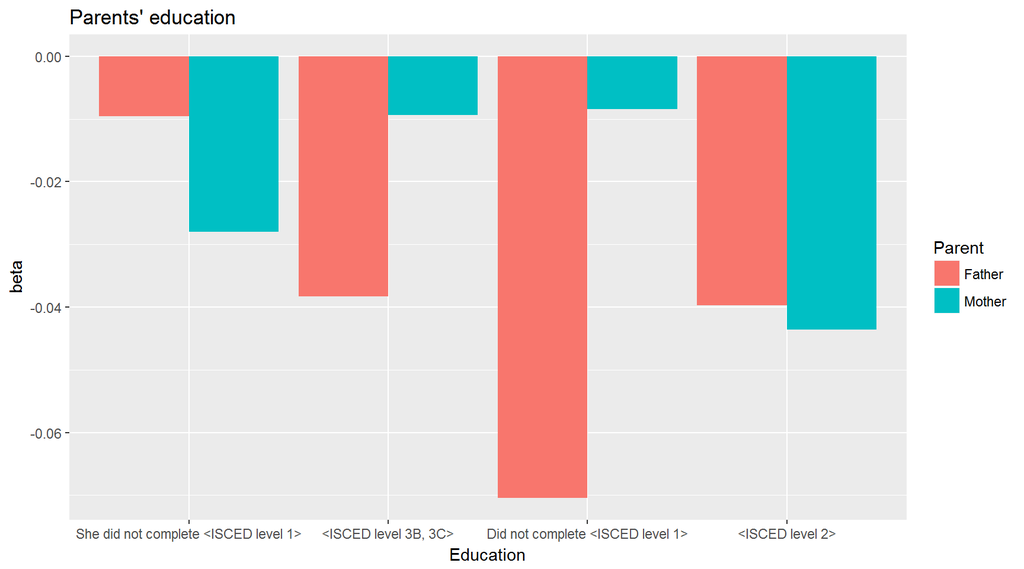

```r
mother_edu.names = c(levels(qTime34$mother_edu)[2:4], "Did not complete <ISCED level 1>")

father_edu.names = mother_edu.names

coeff.df <- data.frame(beta = c(unname(coeff[58:61]), unname(coeff[62:65])), name = c(mother_edu.names, father_edu.names), Parent = c("Mother", "Mother", "Mother", "Mother", "Father", "Father", "Father", "Father"))

ggplot(coeff.df, aes(fill=Parent, x = reorder(name, -beta), y=beta)) + geom_bar(position = 'dodge', stat = 'identity') + labs(x = 'Education') + ggtitle("Parents' education")
```

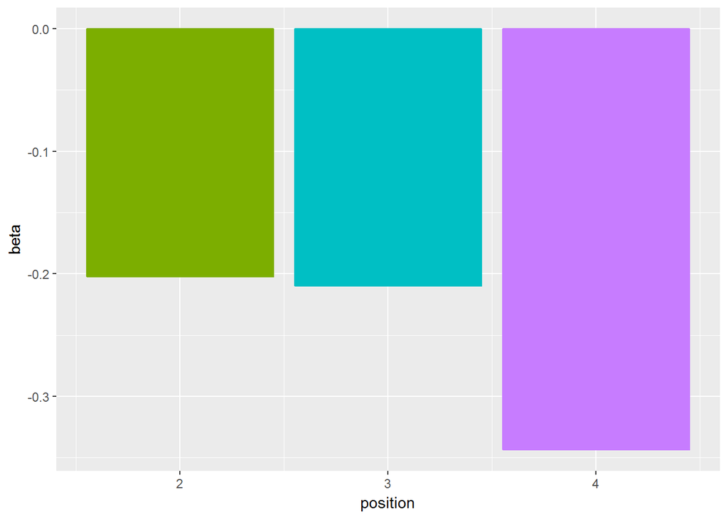

```r
gg_color_hax = c("#7CAE00", "#00BFC4", "#C77CFF")

coeff.df <- data.frame(beta = coeff[68:70], position = 2:4)

ggplot(coeff.df, aes(position, beta)) + geom_bar(position = 'dodge', stat = 'identity', fill=gg_color_hax, color=gg_color_hax)
```

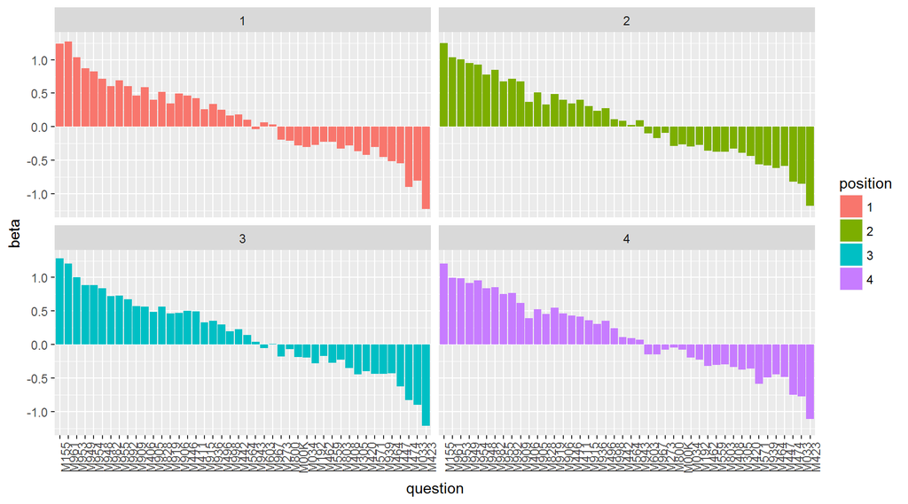

```r
coeff.p <- unlist(lapply(X = coeff.names[71:246], FUN = function(x) substr(x, 9, 9)))
coeff.q <- unlist(lapply(X = coeff.names[71:246], FUN = function(x) substr(x, 19, 22)))
coeff.df <- data.frame(beta = unname(coeff[71:246]), position = coeff.p, question = coeff.q)

ggplot(coeff.df, aes(fill=position, x=reorder(question, -beta), y=beta)) + facet_wrap(~position) + geom_bar(position = 'dodge', stat = 'identity')+ theme(axis.text.x = element_text(angle = 90, hjust = 1)) + labs(x = 'question')
```

## 3.6 Diagnostyka modelu

Na wykresie Q-Q poniżej widać, że rozkład reszt znacznie odbiega w ogonach od normalnego.

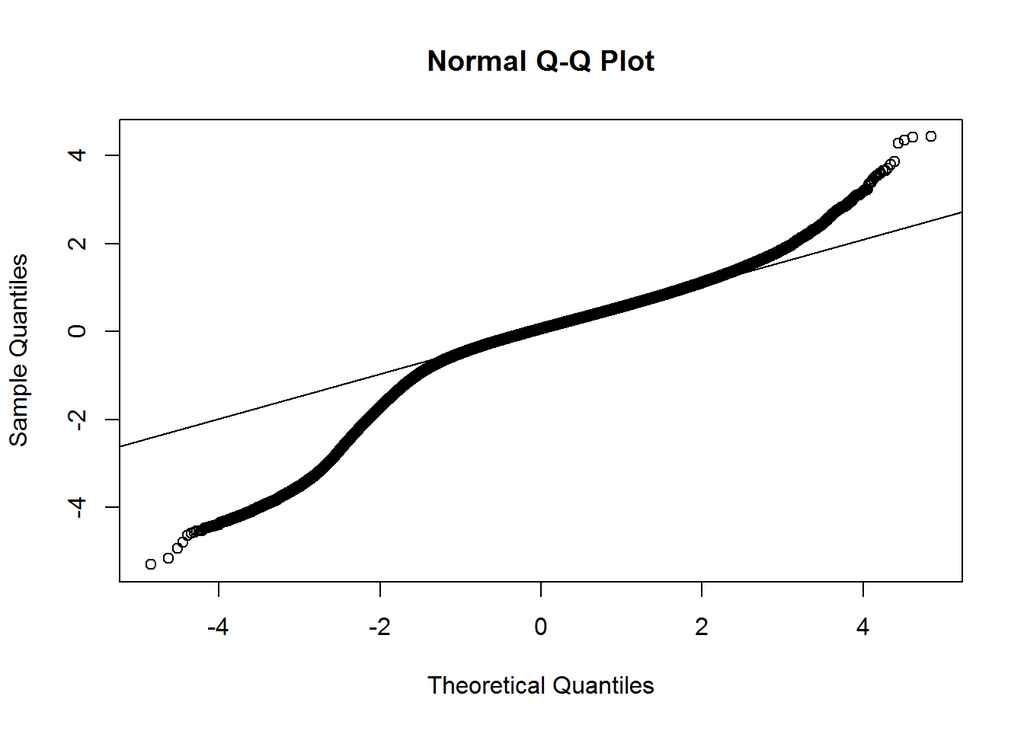

```r
qqnorm(model$res)
qqline(model$res)
```

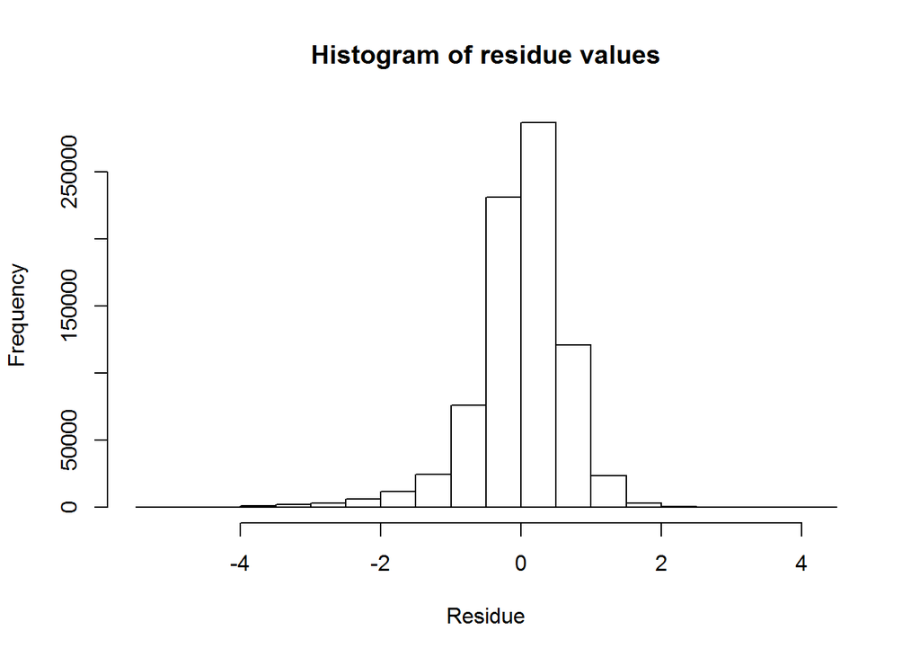

```r
hist(model$res, main="Histogram of residue values", xlab="Residue")
```

Model nie przechodzi testu heteroskedastyczności reszt Breuscha-Pagana:

```r
lmtest::bptest(model)
```

```
##
##  studentized Breusch-Pagan test
##
## data:  model
## BP = 28488, df = 245, p-value < 2.2e-16
```

Model nie przechodzi też testu Durbina-Watsona - istnieje autokorelacja między resztami:

```r
lmtest::dwtest(model, alternative = "two.sided")
```

```
##
##  Durbin-Watson test
##
## data:  model
## DW = 1.4472, p-value < 2.2e-16
## alternative hypothesis: true autocorrelation is not 0
```